# Project Python Foundations: FoodHub Data Analysis

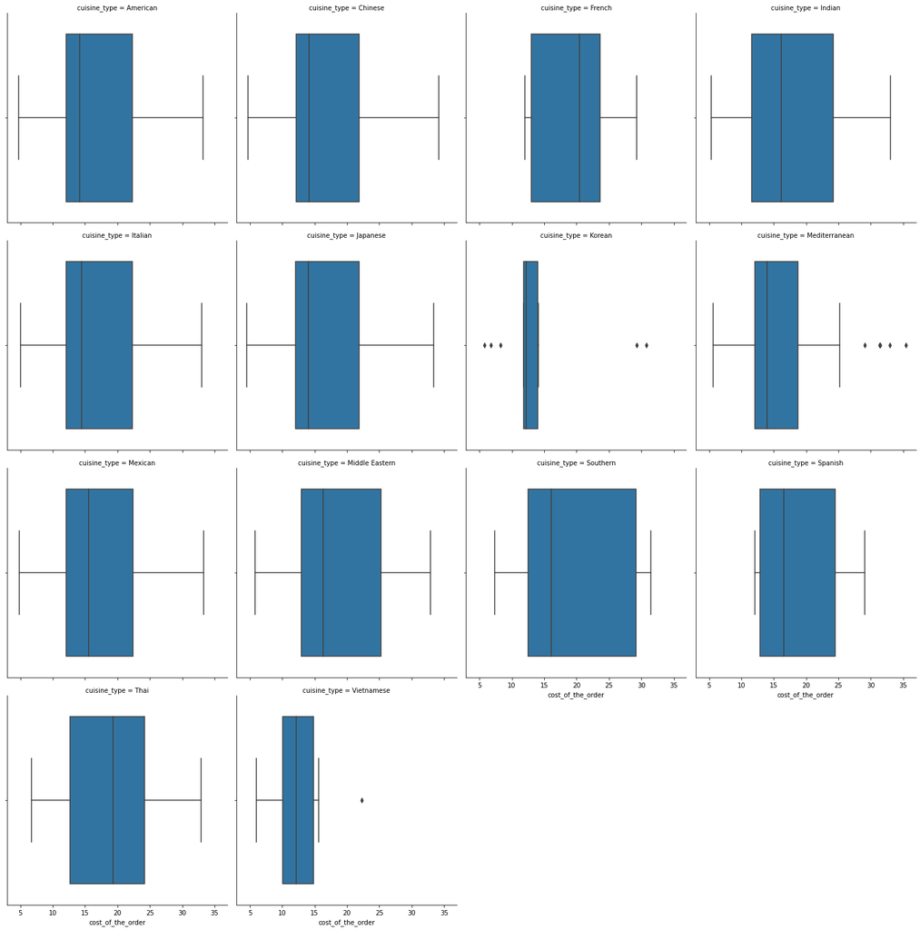

```python
sns.catplot(x='cost_of_the_order',
             col='cuisine_type',
             data=df,
             col_wrap=4,
             kind="box")
plt.show()
```

observation: The cost of the order for all the cuisine types does not show significant variation except for Korean, Mediterranean and Vietnamese.

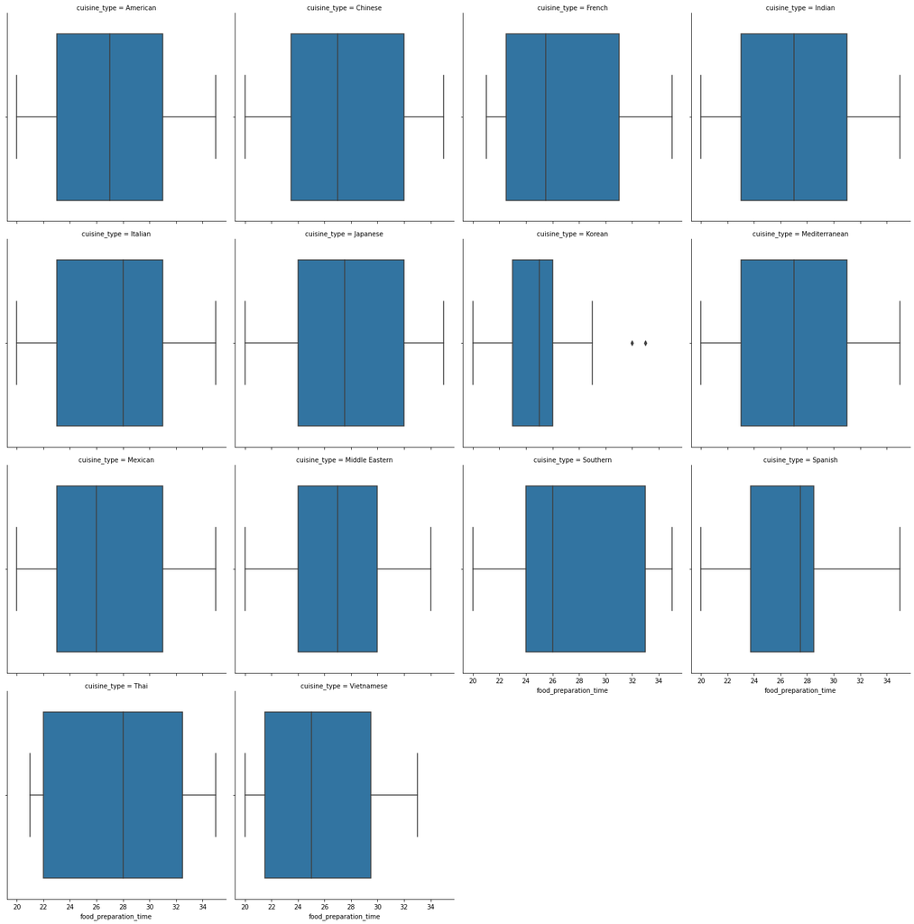

```python
sns.catplot(x='food_preparation_time',
             col='cuisine_type',
             data=df,
             col_wrap=4,
             kind="box")
plt.show()
```

observation: The korean cuisine shows a right skew.

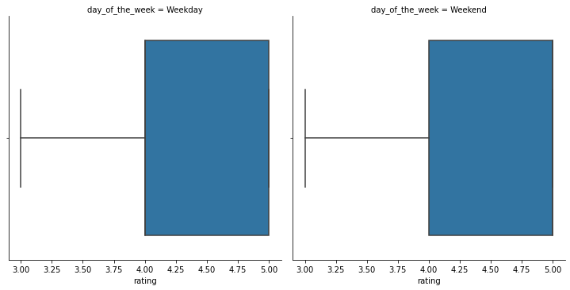

```python
sns.catplot(x='rating',
             col='day_of_the_week',
             data=per_rate,
             col_wrap=6,
             kind="box")
plt.show()
```

observation: The rating does not have a strong relationship with day of the week.

# Question 13: Suppose the company wants to provide a promotional offer in the advertisement of the restaurants. The condition to get the offer is that the restaurants must have a rating count of more than 50 and the average rating should be greater than 4. Write the code to find the restaurants fulfilling the criteria to get the promotional offer.

```python
per_rate=df[df['rating'] !='Not given']
per_rate
```

|  | order_id | customer_id | restaurant_name | cuisine_type | cost_of_the_order | day_of_the_week | rating | food_preparation_time | delivery_time |
| --- | --- | --- | --- | --- | --- | --- | --- | --- | --- |
| 2 | 1477070 | 66393 | Cafe Habana | Mexican | 12.23 | Weekday | 5 | 23 | 28 |
| 3 | 1477334 | 106968 | Blue Ribbon Fried Chicken | American | 29.20 | Weekend | 3 | 25 | 15 |
| 4 | 1478249 | 76942 | Dirty Bird to Go | American | 11.59 | Weekday | 4 | 25 | 24 |
| 5 | 1477224 | 147468 | Tamarind TriBeCa | Indian | 25.22 | Weekday | 3 | 20 | 24 |
| 7 | 1477859 | 89574 | Barbounia | Mediterranean | 5.97 | Weekday | 3 | 33 | 30 |
| ... | ... | ... | ... | ... | ... | ... | ... | ... | ... |
| 1889 | 1478190 | 94152 | RedFarm Broadway | Chinese | 8.68 | Weekday | 3 | 33 | 30 |
| 1890 | 1477316 | 164776 | TAO | Japanese | 15.67 | Weekend | 5 | 20 | 22 |
| 1893 | 1476701 | 292602 | Chipotle Mexican Grill $1.99 Delivery | Mexican | 22.31 | Weekend | 5 | 31 | 17 |
| 1894 | 1477421 | 397537 | The Smile | American | 12.18 | Weekend | 5 | 31 | 19 |
| 1896 | 1477513 | 64151 | Jack's Wife Freda | Mediterranean | 12.18 | Weekday | 5 | 23 | 31 |

1162 rows × 9 columns

```python
per_rate.rating = per_rate.rating.astype('int')
```

```python
per_rate.info()
```

```
<class 'pandas.core.frame.DataFrame'>
Int64Index: 1162 entries, 2 to 1896
Data columns (total 9 columns):
 #   Column                 Non-Null Count  Dtype
---  ------                 --------------  -----
 0   order_id               1162 non-null   int64
 1   customer_id            1162 non-null   int64
 2   restaurant_name        1162 non-null   object
 3   cuisine_type           1162 non-null   object
 4   cost_of_the_order      1162 non-null   float64
 5   day_of_the_week        1162 non-null   object
 6   rating                 1162 non-null   int32
 7   food_preparation_time  1162 non-null   int64
 8   delivery_time          1162 non-null   int64
dtypes: float64(1), int32(1), int64(4), object(3)
memory usage: 86.2+ KB
```

```python
win=per_rate.groupby(['restaurant_name'])['rating'].mean().sort_values(ascending=False).reset_index()
win
```

|  | restaurant_name | rating |
| --- | --- | --- |
| 0 | 'wichcraft | 5.0 |
| 1 | Ravagh Persian Grill | 5.0 |
| 2 | Chola Eclectic Indian Cuisine | 5.0 |
| 3 | Chote Nawab | 5.0 |
| 4 | Junoon | 5.0 |
| ... | ... | ... |
| 151 | Woorijip | 3.0 |
| 152 | Byblos Restaurant | 3.0 |
| 153 | Pepe Giallo | 3.0 |
| 154 | Sushi Choshi | 3.0 |
| 155 | Sarabeth's West | 3.0 |

156 rows × 2 columns

```python
win1= win[win['rating'] > 4]
win1
```

|  | restaurant_name | rating |
| --- | --- | --- |
| 0 | 'wichcraft | 5.000000 |
| 1 | Ravagh Persian Grill | 5.000000 |
| 2 | Chola Eclectic Indian Cuisine | 5.000000 |
| 3 | Chote Nawab | 5.000000 |
| 4 | Junoon | 5.000000 |
| ... | ... | ... |
| 105 | Cafe Mogador | 4.153846 |
| 106 | ilili Restaurant | 4.153846 |
| 107 | Parm | 4.128205 |
| 108 | Rubirosa | 4.125000 |
| 109 | Bareburger | 4.058824 |

110 rows × 2 columns

```python
rate_count = per_rate.groupby(['restaurant_name'])['rating'].count().sort_values(ascending=False).reset_index()
rate_count
```

|  | restaurant_name | rating |
| --- | --- | --- |
| 0 | Shake Shack | 133 |
| 1 | The Meatball Shop | 84 |
| 2 | Blue Ribbon Sushi | 73 |
| 3 | Blue Ribbon Fried Chicken | 64 |
| 4 | RedFarm Broadway | 41 |
| ... | ... | ... |
| 151 | Frank Restaurant | 1 |
| 152 | Socarrat Paella Bar | 1 |
| 153 | El Parador Cafe | 1 |
| 154 | Lucky Strike | 1 |
| 155 | 'wichcraft | 1 |

156 rows × 2 columns

```python
rate_count1=rate_count[rate_count['rating'] > 50]
rate_count1
```

|  | restaurant_name | rating |
| --- | --- | --- |
| 0 | Shake Shack | 133 |
| 1 | The Meatball Shop | 84 |
| 2 | Blue Ribbon Sushi | 73 |
| 3 | Blue Ribbon Fried Chicken | 64 |

```python
offer_merge= win1.merge(rate_count1,on='restaurant_name')
offer_merge
```

|  | restaurant_name | rating_x | rating_y |
| --- | --- | --- | --- |
| 0 | The Meatball Shop | 4.511905 | 84 |
| 1 | Blue Ribbon Fried Chicken | 4.328125 | 64 |
| 2 | Shake Shack | 4.278195 | 133 |
| 3 | Blue Ribbon Sushi | 4.219178 | 73 |

observation: Shake Shack,Blue Ribbon Fried Chicken,Blue ribbon Sushi and The Meatball Shop are the 4 restaurants fulfilling the necessary criteria for the promotional offer.

# Question 14: Suppose the company charges the restaurant 25% on the orders having cost greater than 20 dollars and 15% on the orders having cost greater than 5 dollars. Write the code to find the net revenue generated on all the orders given in the dataset.

```python
per_charge20=df[df['cost_of_the_order'] > 20.00]
```

```python
per_charge15=df[df['cost_of_the_order'] < 20.00]
```

```python
per_charge5= per_charge15[per_charge15['cost_of_the_order'] > 5.00]
```

```python
profit=per_charge5['cost_of_the_order'].sum()
profit15=profit*(15/100)
profit15
```

```
2477.5755000000004
```

```python
profit2=per_charge20['cost_of_the_order'].sum()
profit20=profit2*(25/100)
profit20
```

```
3688.7275
```

```python
total_net=profit15+profit20
total_net
```

```
6166.303
```

```python
per_charge_less= df[df['cost_of_the_order'] < 5.00]
```

```python
per_charge_less['cost_of_the_order'].sum()
```

```
42.74
```

observation: The net revenue generated on all the orders costing more than 5 dollars is 6166.303 dollars, we have excluded an amount of 42.74 dollars which was generated by the orders having less than 5 dollars .

# Question 15: Suppose the company wants to analyze the total time required to deliver the food. Write the code to find out the percentage of orders that have more than 60 minutes of total delivery time.

```python
foodhubnew = df[['restaurant_name',"food_preparation_time", 'delivery_time']].copy()
```

```python
foodhubnew["total_delivery_time"] = df['food_preparation_time']+ df['delivery_time']
```

```python
foodhubnew
```

|  | restaurant_name | food_preparation_time | delivery_time | total_delivery_time |
| --- | --- | --- | --- | --- |
| 0 | Hangawi | 25 | 20 | 45 |
| 1 | Blue Ribbon Sushi Izakaya | 25 | 23 | 48 |
| 2 | Cafe Habana | 23 | 28 | 51 |
| 3 | Blue Ribbon Fried Chicken | 25 | 15 | 40 |
| 4 | Dirty Bird to Go | 25 | 24 | 49 |
| ... | ... | ... | ... | ... |
| 1893 | Chipotle Mexican Grill $1.99 Delivery | 31 | 17 | 48 |
| 1894 | The Smile | 31 | 19 | 50 |
| 1895 | Blue Ribbon Sushi | 31 | 24 | 55 |
| 1896 | Jack's Wife Freda | 23 | 31 | 54 |
| 1897 | Blue Ribbon Sushi | 28 | 24 | 52 |

1898 rows × 4 columns

```python
tot_del_time= foodhubnew[foodhubnew['total_delivery_time'] > 60]
tot_del_time
```

|  | restaurant_name | food_preparation_time | delivery_time | total_delivery_time |
| --- | --- | --- | --- | --- |
| 7 | Barbounia | 33 | 30 | 63 |
| 10 | Big Wong Restaurant _¤¾Ñ¼ | 34 | 28 | 62 |
| 19 | Blue Ribbon Sushi | 35 | 26 | 61 |
| 24 | Cafe Mogador | 32 | 29 | 61 |
| 54 | Jack's Wife Freda | 35 | 29 | 64 |
| ... | ... | ... | ... | ... |
| 1869 | J. G. Melon | 35 | 26 | 61 |
| 1873 | Shake Shack | 35 | 28 | 63 |
| 1875 | Amy Ruth's | 32 | 33 | 65 |
| 1880 | Shake Shack | 35 | 27 | 62 |
| 1889 | RedFarm Broadway | 33 | 30 | 63 |

200 rows × 4 columns

```python
a1=tot_del_time['total_delivery_time'].count()
b1=foodhubnew['total_delivery_time'].count()
percentage_totaldelivery_time=(a1/b1)*100
percentage_totaldelivery_time
```

```
10.537407797681771
```

observation:The percentage of orders that have more than 60 minutes of total delivery time is 10.5374%.

# Question 16: Suppose the company wants to analyze the delivery time of the orders on weekdays and weekends. Write the code to find the mean delivery time on weekdays and weekends. Write your observations on the results.

```python
weekday_deltime=df[df['day_of_the_week'] =='Weekday']
weekday_deltime['delivery_time'].mean()
```

```
28.340036563071298
```

```python
weekend_deltime=df[df['day_of_the_week'] =='Weekend']
weekend_deltime['delivery_time'].mean()
```

```
22.4700222057735
```

observations: 1. The mean delivery time on weedays is 28.34 min. 2. The mean deliver time on weekends is 22.47 min. 3. The delivery time during the weekends is less compared to that on weekdays.

# Conclusion and Recommendations

Question 17: Write the conclusions and business recommendations derived from the analysis.

# conclusions

Analyzing a Food Hub data set having 1898 rows and 9 columns, the data set provided had different variables like the order id,customer id ,the time needed for preparation and delivery.it also shows the ratings provided. They want to analyze the data to get a fair idea about the demand of different restaurants which will help them in enhancing their customer experience. I have Performed the data analysis to find answers to these questions that will help the company to improve the business.

CONCLUSIONS:

1. The number of orders are definetly more during the weekends compared to weekdays.
2. American cuisine is the most prefered cuisine .
3. shake Shack restaurant is the most preferred restaurant among the customers.
4. Delivery time is less during the weekends.
5. vietnamese cuisine has the least number of orders.
6. The net profit made by the orders costing more than 20 dollars is more than the profit made by the orders costing between 5 and 20 dollars.
7. Most preferred restaurants have average rating more than 4.

# Recommendation to business

1. Since the number of orders are more on weekends and the delivery time is also less during weekends, it is the best time to attract new customers and make maximum profit.
2. The best way to attract new customers or to increase the number of orders of the least preferred cuisines, it is necessary to use some marketing strategies, like discounts,free kid's meal etc.
3. American cuisine is the most prefered cuisine , so the food hub can include more American restaurants to their chain of restaurants. 4.To increase business during the weekdays, new marketing strategies like gift vouchers etc. can be introduced. Also, if they can reduce the food preparation time(pre-prep),without compromizing the quality, they can reduce the total delivery time.
4. Food Delivery persons can avoid the routes causing delays, which can help them to reduce the delivery time.